# Numerical evaluation of Tweedie probability functions

QANZIAM

Peter K. Dunn

University of the Sunshine Coast

16 November 2026

# Introduction

## Data types: Continuous data

- **Continuous on real line** (e.g., altitude): $Y \in \mathbb{R}$.
  - Model using a normal distribution (standard regression).
- **Positive continuous** (e.g., crop yields): $Y\in \mathbb{R}_{+}$.
  - Model using gamma distribution (a generalized linear model; GLM).
- **Proportions** (e.g., cloud cover): $Y\in [0, 1]$.
  - Model using beta distribution.
- **Directions** (e.g., movements of animals): $Y\in [0, 2\pi)$.
  - Model using von Mises distribution.

[figure not shown]

## Data types: Discrete data

- **Discrete** (e.g., counts of insects): $Y \in \mathbb{N}$
  - Model using Poisson distribution (a GLM).
- **Binomial counts** (e.g., seed germination): $Y\in \{0, 1, 2, \dots, m\}$.
  - Model using binomial distribution (a GLM).

[figure not shown]

## Data types: Mixed data

- **Continuous data with exact zeros** (e.g., rainfall): $Y\in \{0\}\cup \mathbb{R}_+$.
  - What probability model…?

[figure not shown]

- Rainfall (e.g., Yunus et al. (2017), Hasan and Dunn (2010); Dunn (2004)).
- Fisheries: Catch per unit effort (CPUE) (e.g., Candy (2004); Dunn (2009)).
- Root length density of trees (e.g., Dunn and Smyth (2005); Silva et al. (1999)).
- Insurance payouts (e.g., Haberman and Renshaw (1996)).
- Alcohol consumption in teenagers (e.g., Gilchrist and Drinkwater (1999)).
- Survival analysis (e.g., Aalen (1992)).
- Transcriptomics (e.g., Mallick et al. (2022); Wu et al. (2023)).

## Mixed data: models

Continuous data with exact zeros can appear for different reasons:

[figure not shown]

**Censoring**

- A detection or measurement limitation.

Pollutant or chemical concentrations below the instrument’s detection limit.

[figure not shown]

**Structure**

- Underlying structure leads to mixed data.

Daily rainfall: day with no rain, amount exactly 0; otherwise a positive continuous amount.

## PG models: model development

- **Number of precipitation events in any month** $N$.
  - $N$ has a *Poisson* distribution: $N\sim\text{Pois}(\lambda)$ (note: $N$ could be zero).
- **Precipitation amounts per event** when rain falls $R$.
  - Rainfall event $i$ receives rainfall $R_i$; *gamma* distribution: $\text{Gam}(-\alpha, \gamma)$.
- *Total* monthly precipitation, $Y$.
  - Poisson sum of gamma random variables:
    $$Y
    =
    \begin{cases}
    0 & \text{if $N = 0$};\\
    R_1 + R_2 + \cdots + R_N & \text{if $N > 0$}.
    \end{cases}$$

[figure not shown]

## PG models: development

The probability distribution of a **Poisson sum of gamma variables**:

- can be deduced by working with cumulant generating functions.
- is complicated: generally **no closed form** apart from well-known special cases:
  - Normal distributions.
  - Gamma distributions.
  - Poisson distributions.
- **Poisson–gamma models** belong to the **exponential dispersion model** (EDM) family, so fit the GLM framework (Dunn and Smyth (2018)).

[figure not shown]

## PG models

- EDMs have **mean** $\text{E}[Y] = \mu$.
- EDMs have **variance** $\text{var}[Y] = \phi V(\mu)$, where:
  - $\phi > 0$ is some constant (the **dispersion parameter**);
  - $V(\mu)$ is the **variance function**, uniquely defining the EDM distribution.

## Tweedie (power-variance) models

| **Distribution** | **Var fn $V(\mu)$** |
| --- | --- |
| Normal distribution | $V(\mu) = \mu^0 = 1$ |
| Poisson distribution, if $\phi=1$ | $V(\mu) = \mu^1 = \mu$ |
| Gamma distribution | $V(\mu) = \mu^2$ |
| Inverse Gaussian | $V(\mu) = \mu^3$ |
| ‘Equivalent’ to $y^* = 1/y$ transform in regression | $V(\mu) = \mu^4$ |

## Tweedie (power-variance) models

| **Distribution** | **Var fn $V(\mu) = \mu^\xi$** | $\xi$ |
| --- | --- | --- |
| Normal distribution | $V(\mu) = 1$ | $0$ |
| Poisson distribution, if $\phi=1$ | $V(\mu) = \mu$ | $1$ |
| Gamma distribution | $V(\mu) = \mu^2$ | $2$ |
| Inverse Gaussian | $V(\mu) = \mu^3$ | $3$ |
| ‘Equivalent’ to $y^* = 1/y$ transform in regression | $V(\mu) = \mu^4$ | $4$ |
| Tweedie (power-variance) | $V(\mu) = \mu^\xi$ | $\notin (0,1)$ |
| Poisson–gamma | $V(\mu) = \mu^\xi$ | $\in (1, 2)$ |

## Tweedie (power-variance) models

| **Range of $\xi$** | **Distribution Type** |
| --- | --- |
| $\xi \le 0$ | Continuous on $(-\infty, \infty)$; e.g., Normal ($\xi = 0$) |
| $0 < \xi < 1$ | **No distributions exist** |
| $\xi = 1$ | Non-negative discrete; e.g., Poisson ($\xi = 1$ and $\phi = 1$) |
| $1 < \xi < 2$ | Mixed on $y \ge 0$ (mass at $y = 0$); Poisson–gamma distributions |
| $\xi \ge 2$ | Continuous on $(0, \infty)$ e.g.: Gamma ($\xi=2$); inv. Gauss ($\xi = 3$) |

## Power-variance densities: examples

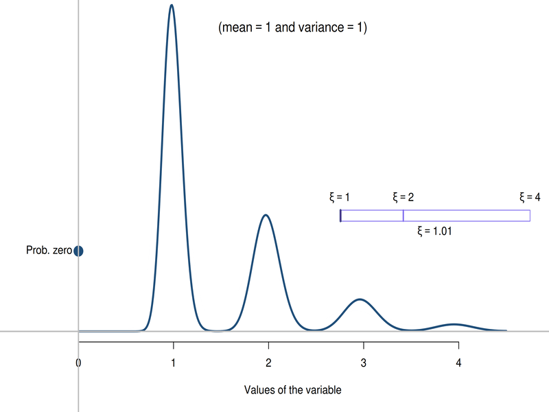

## Tweedie distributions

The Tweedie family is a three-parameter family of distributions:

- $\mu$ (the **mean**);
- $\phi > 0$ (the **dispersion parameter**);
- $\xi$ (the **index parameter**: *which* Tweedie distribution, sometimes denoted as $p$).
- The estimation of $\mu$ follows standard GLM algorithms… if $\xi$ is known.
- Tweedie GLMs can be fitted in Genstat, R, SPSS, etc.

[figure not shown]

## Tweedie distributions: evaluation

- Two important functions for describing a distribution:
  - Probability density function (PDF): how probability is **distributed**.
  - Distribution function (DF): how probability **accumulates**.

Use **PDF** $f_{\xi}(y)$ to:

- **estimate** a value for $\xi$ (and hence fitting a model…).
- **compute** maximum likelihood estimates.
- **compute** the AIC.

Use **CDF** $F_{\xi}(y)$ to:

- **evaluate models**: computing quantiles and $p$-values.
- **compute quantile residuals**.
- **generate** random numbers.

## Tweedie distributions: evaluation

**Tweedie PDFs** must be, in general, evaluated numerically:

- Saddlepoint *approximation*: accurate for small dispersion $\phi$.
- Infinite series (Dunn and Smyth 2005).
- Infinite oscillating integrals (Dunn and Smyth 2008).

**Tweedie DFs** must be evaluated numerically (Dunn and Smyth 2027) :

- Saddlepoint *approximation*: accurate for small dispersion $\phi$.
- Direct integration of the PDF.
- Infinite series for $1 <\xi < 2$.
- Infinite oscillating integrals.

# PDF evaluation: series

## PDF evaluation: series

- For $1 < \xi < 2$: PDF is in terms of Wright’s generalized Bessel function $W(y, \phi, \xi)$:
  $$\sum_{j = 1}^\infty
  \frac{y^{-j(2 - \xi)/(1 - \xi)} (\xi - 1)^{(2 - \xi)/(1 - \xi) j}}
  {\phi^{j(1-(2 - \xi)/(1 - \xi))}(2 - \xi)^j\, j!\,\Gamma\big(-j(2 - \xi)/(1 - \xi)\big)}$$
- A similar expression exists for $\xi > 2$.
- Evaluating in principle is easy: sum over many terms $j$… but:
  - Sometimes the terms are a *long way* from $j = 1$.
  - Sometimes a very large number of terms are needed.
- So **which** terms, and **how many** terms, must be summed?

## PDF evaluation: series strategy

- Using Stirling’s approximation for the gamma function, plus other approximations…
- … then treat the index of summation $j$ as continuous…
- … and differentiate to find where the terms reach a maximum in terms of $j$.

Then: sum terms either side of the maximum until the contributions are negligible.

[figure not shown]

## PDF evaluation: series

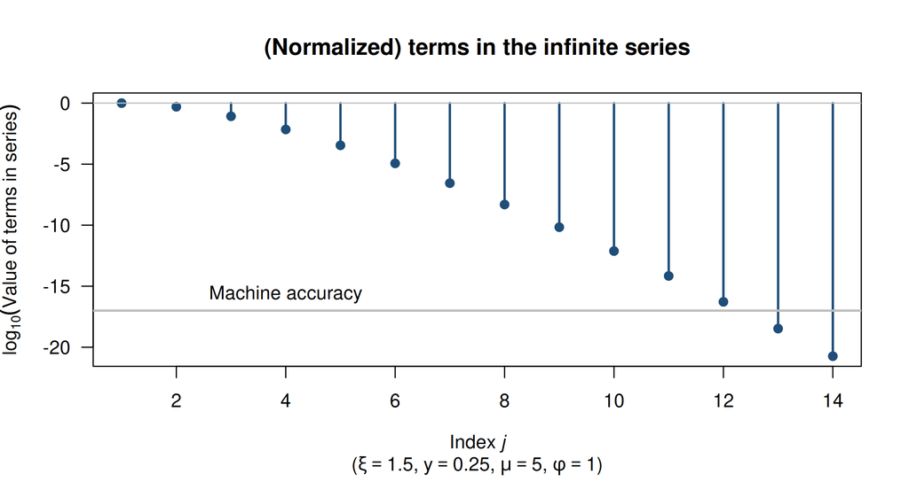

## PDF evaluation: series

Challenges:

- Sometimes, the **number of terms** required is in the thousands.
- Sometimes, the **contributions** don’t start until $j = 100\,000+$.
- Sometimes, the numerical evaluation is tricky (e.g., factorials involving index $j$).

## PDF evaluation: series

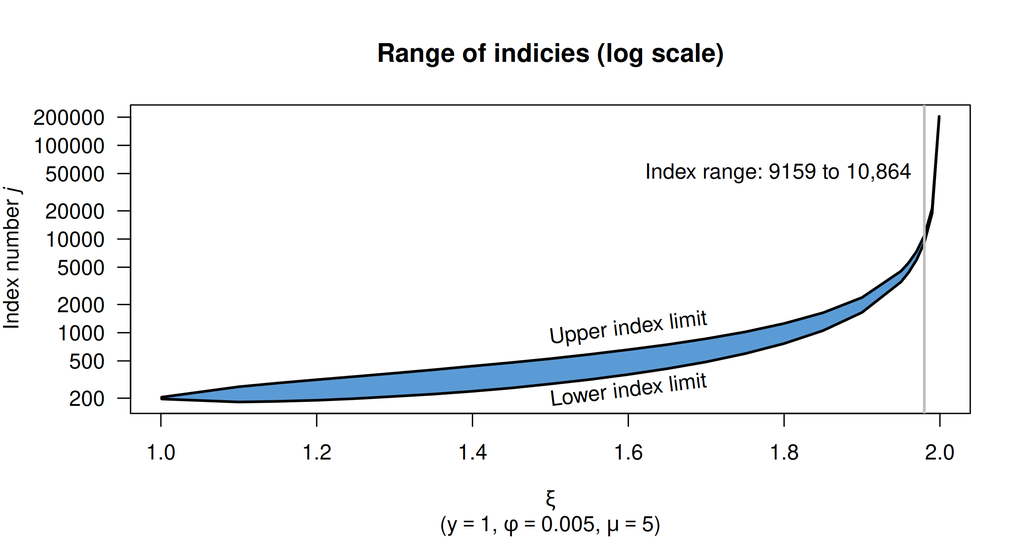

## PDF evaluation: series performance

- The series method works well:
  - only summing positive terms, so machine accuracy is achievable.
- However, the number of necessary terms grows without bound as $\xi\to 2$ and as $\Pr(Y=0) \to 0$.
- In these cases, the method becomes very slow.

[figure not shown]

# PDF evaluation: Fourier inversion

## PDF evaluation: Fourier inversion

- Tweedie distribution have no closed form density…
- … but have relatively simple moment generating functions (MGFs):

$$\begin{align*}
M_Y(t)
= \mathrm{E}\left[e^{tY}\right]
&= \int_{-\infty}^{\infty} e^{ty} f(y)\,dy\quad\text{(by definition)}\\
&= \exp\left\{\frac{\kappa(\theta + t\phi) - \kappa(\theta)}{\phi}\right\},
\end{align*}$$
where
$$\theta = \frac{\mu^{1-\xi} - 1}{1-\xi}, \qquad \kappa(\theta) = \frac{\mu^{2-\xi} - 1}{2-\xi}.$$

- $\xi = 1$ (Poisson) and $\xi = 2$ (Gamma) have a closed form: focus is $\xi\ne 1, 2$.

## PDF evaluation: Fourier inversion

- Fourier inversion of the **Moment Generating Function** $M_Y(t)$:
  $$\begin{align*}
  f_Y(y)
  &=
  \frac{1}{2\pi} \int_{-\infty}^{\infty} \exp[ \log M_Y(it) - ity]\, dt\\
  &=
  \frac{1}{2\pi} \int_{-\infty}^{\infty} \exp[ k(t) ] \, dt
  \end{align*}$$
  where $i = \sqrt{-1}$.

## PDF evaluation: Fourier inversion

- Extracting the **real components**:
  $$\begin{align*}
  f_Y(y)
  &=
  \frac{1}{2\pi} \int_{-\infty}^{\infty} \exp[ \Re k(t) ]\, \cos \Im k(it) \, dt\\
  &=
  \frac{1}{\pi} \int_{0}^{\infty} \exp[ \Re k(t) ]\, \cos \Im k(it) \, dt,
  \end{align*}$$
- This is an infinite, oscillating integral:
  - **exponentially decaying** (i.e., $\exp[ \Re k(t) ]$); and
  - **oscillating** (i.e., $\cos \Im k(it)$) function.

## PDF evaluation: Fourier inversion

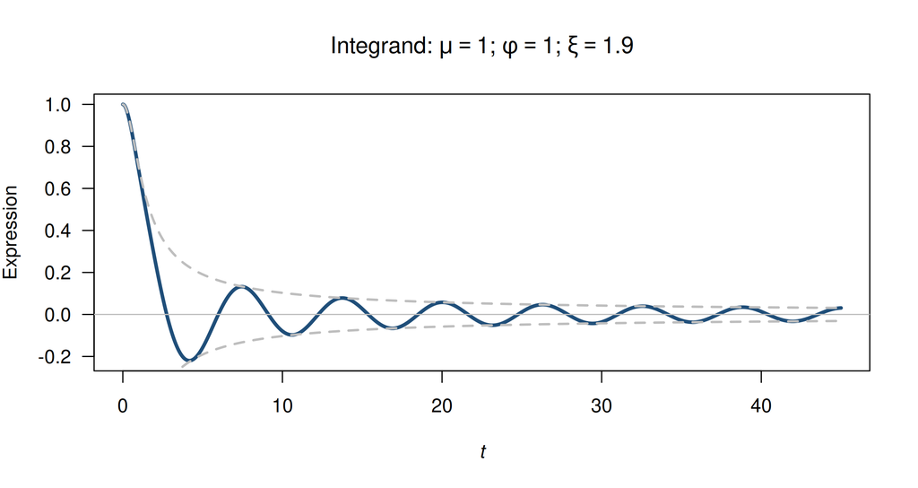

## PDF evaluation: Fourier inversion

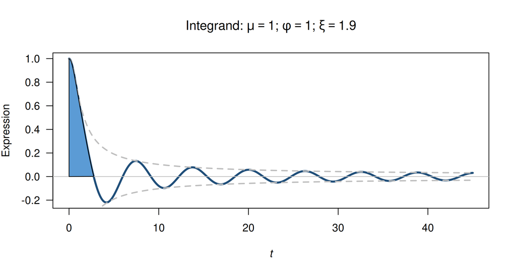

## PDF evaluation: Fourier inversion

$$f_Y(y)
=
\frac{1}{\pi} \int_{0}^{\infty} \exp[ \Re k(t) ]\, \cos \Im k(it) \, dt$$

- The integrand zeros occur when
  $$\cos \Im k(t) = 0 \implies \Im k(t) = \frac{\pi}{2} + m\pi\quad\text{for integer $m$.}$$
- To find the zeros, the behaviour of $\Im k(t)$ needs to be studied…

## PDF evaluation: Fourier inversion

$\tfrac{d}{dt} \Im k(t) < 0$, so solve $\Im k(t) = \frac{\pi}{2} + m\pi$ for $m = -1, -2, ...$

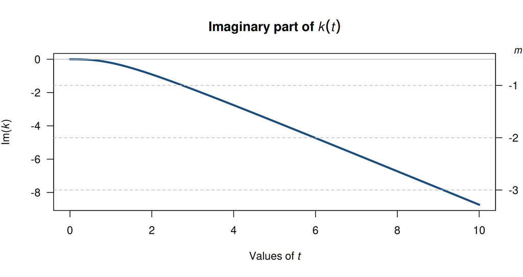

## PDF evaluation: Fourier inversion

$\tfrac{d}{dt} \Im k(t) > 0$; max. value $< \pi/2$, so solve $\Im k(t) = \frac{\pi}{2} + m\pi$ for $m = -1, -2, ...$

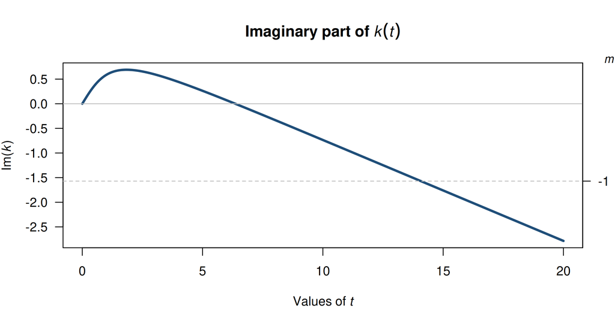

## PDF evaluation: Fourier inversion

$\tfrac{d}{dt} \Im k(t) > 0$; max. value $\ge \pi/2$, so solve $\Im k(t) = \frac{\pi}{2} + m\pi$ for $m = 0, 0 -1, ...$

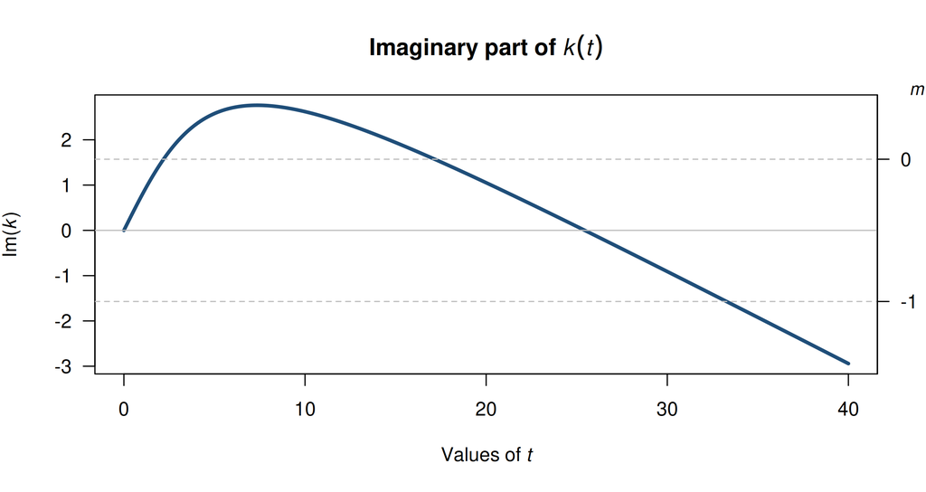

## PDF evaluation: Fourier inversion

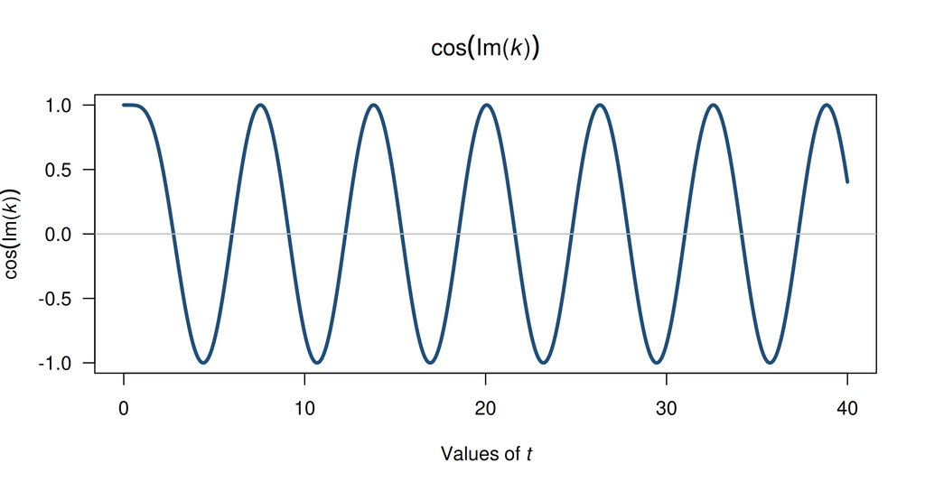

## PDF evaluation: Fourier inversion

[figure not shown]

**In principle**, the algorithm is simple:

- Find the zeros of the integrand…
- Find the area of each integrand (numerical quadrature)…
- Sum the areas.

[figure not shown]

**Challenges**:

1. Accumulated rounding error summing almost-equal, positive and negative areas.
2. Integrands are not always nicely behaved…

## PDF evaluation: Fourier inversion

**Challenge 1**: Rounding error

- Accumulated rounding error summing almost-equal, positive and negative areas.
- **Numerical acceleration** techniques speed the convergence.
- Many acceleration techniques available, depending on the type of decay behaviour.
- We use Sidi’s $W$‑transform (Sidi (1980), Sidi (1982)).

[figure not shown]

## PDF evaluation: acceleration

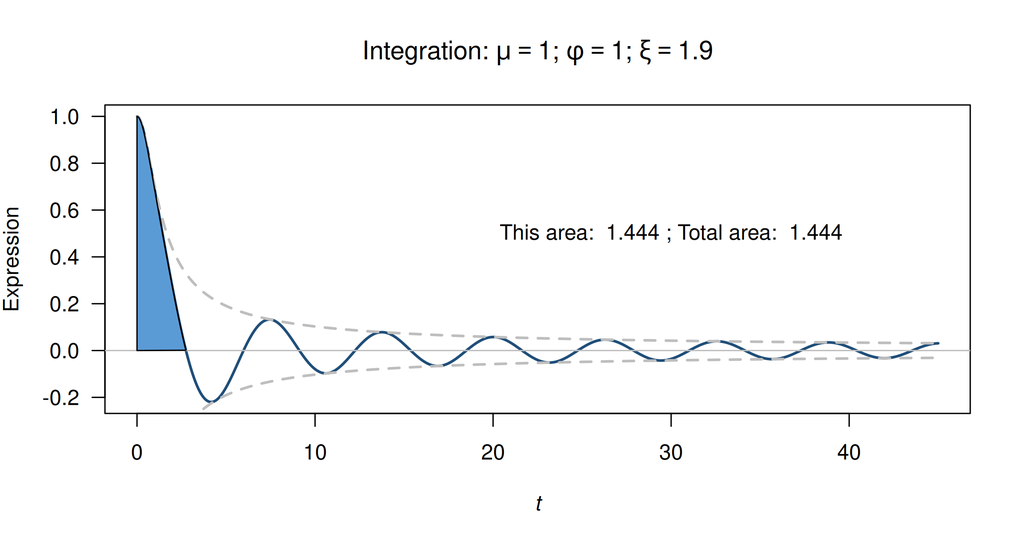

## PDF evaluation: Fourier inversion

**Challenge 2**: Integrand behaviour

- Integrands are not always this nicely behaved…
- Lots of mathematical understanding of the integrand helps.
- Using an identity to simplify the integrand sometimes helps:
  $$f_{\xi}(y; \mu, \phi) = c\,f_{\xi}(cy; c\mu, c^{2-\xi}\phi)$$
  for a constant $c > 0$.
- For example: with $c = 1/\mu$
  $$f_{\xi}(y; \mu, \phi) = \tfrac{1}{\mu} \, f_{\xi}(y/\mu; 1, c^{2-\xi}\phi).$$

[figure not shown]

## PDF evaluation: finding the zeros

Solve $\Im k(t) = \frac{\pi}{2} + m\pi$ for $m = -1, -1, -1, -2, -2, -2, -3, ...$

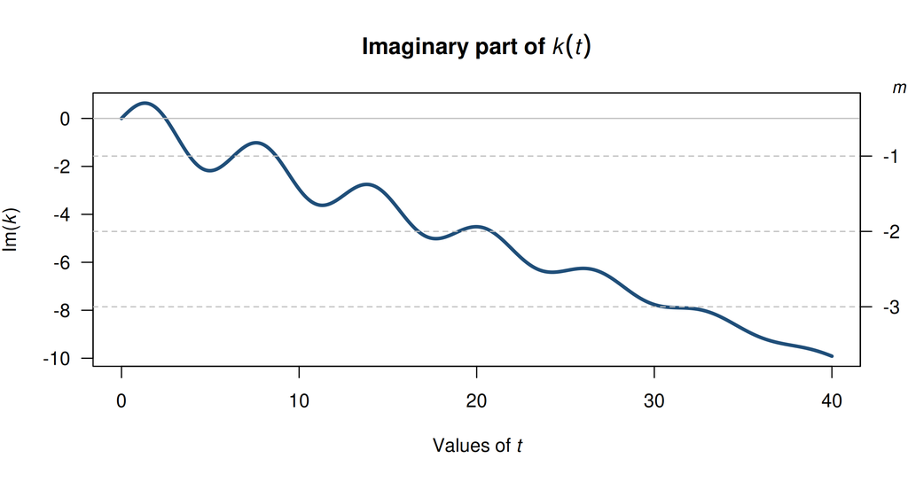

## PDF evaluation: finding the zeros

Oscillations tend to cosine as $t\to\infty$, but this may take a while…

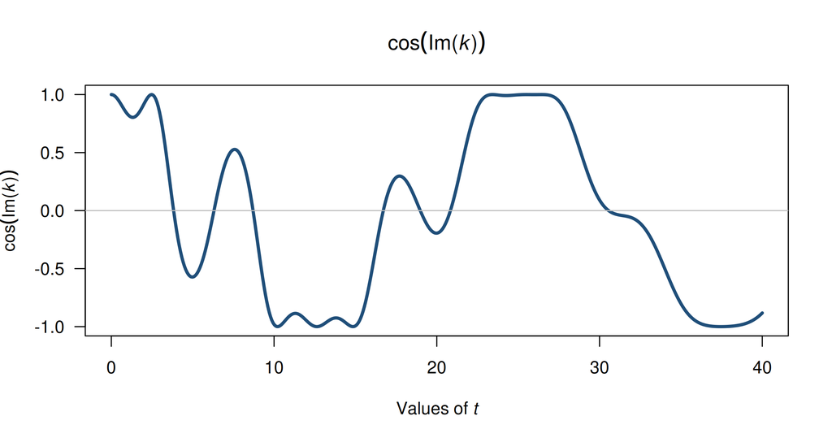

## PDF evaluation: Fourier performance

- The Fourier inversion method works well where the series does not:
  - as $\xi\to 2$ and as $\Pr(Y=0) \to 0$.
- Using the series and Fourier inversion techniques together essentially cover the entire sample space for accurate evaluation.

[figure not shown]

# DF evaluation

## DF Evaluation strategies

- A series expression is available for $1 < \xi < 2$; none for $\xi > 2$.
- For $1 < \xi < 2$: smallest relative error by evaluating series.
- For $\xi > 2$: smallest relative error requires different strategies:
  - Body of distribution: requires Fourier inversion
  - Tails: require direct integration.
  - Small dispersion: requires saddlepoint approximation.

[figure not shown]

## DF evaluation: series for $1<\xi<2$

- DF series evaluation has different strategy than PDF:

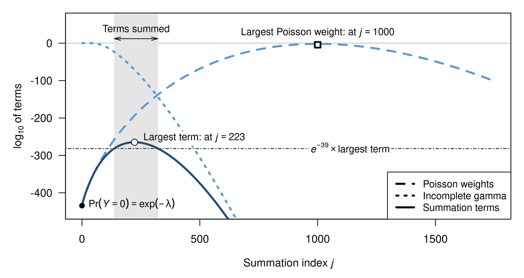

## DF evaluation: strategies for $\xi>2$

- The DF requires high relative accuracy, often in the extreme tails of the distribution.
- **Fourier inversion** has similar ideas as PDF (zero finding; acceleration).
  - Integrand is a damped sin-curve rather than a damped cos-curve.
  - But Fourier inversion has good *absolute* accuracy, but not good *relative* accuracy in the extreme tails.
  - Instead, **direct integration** is useful is the tails.

## DF evaluation: integration for $\xi>2$

- Direct integration of the density:
  $$\begin{aligned}
  F_p(y)
  &= \Pr(Y = 0) + \int_0^y f_p(t)\,dt\quad\text{(by definition)}\\
  &= \Pr(Y = 0) + f_p(y) \int_0^y \frac{f_p(t)}{f_p(y)}\, dt.
  \end{aligned}$$
- Dividing by $f_p(y)$ makes the integrand equal to one at $t = y$, so the integral is not extremely small even when the probability is tiny.
- Computing the result as $\log f_p(y) + \log \int(\cdot)$ prevents underflow.
- The values of $f_p(t)$ come from the numerical methods given earlier:
  - **Computationally costly**; requires very accurate density evaluations!
- However, Gauss–Laguerre is efficient for evaluating the integrals in the tails.

## DF evaluation: saddlepoint approx.

- A cheap computational method is the Lugannani–Rice saddlepoint approximation to the distribution function (Lugannani and Rice 1980; Daniels 1954):
- The saddlepoint (solving $K'(\hat t) = y$) is $\hat t = (y^{1-p} - \mu^{1-p})/\{\phi(1-p)\}$, and
  $$F(y) \approx \Phi(\hat w) + \varphi(\hat w)\left(\frac{1}{\hat w}-\frac{1}{\hat u}\right),$$
  where
  $$\hat w = \operatorname{sgn}(y-\mu)\sqrt{d(y,\mu)/\phi},
  \quad
  \hat u = \hat t\sqrt{\phi V(y)}:$$
  $d(y,\mu)$ is the unit deviance; $\Phi$ and $\varphi$ are the standard normal PDF and DF.
- At very small dispersion (i.e., very small $\phi$), the approximation is very accurate, just where the inversion for $p>2$ loses accuracy.

## DF evaluation: rel. accuracy: $p>2$

| **Regime** | **Method** | **Worst rel. error** |
| --- | --- | --- |
| $\rho\le 10^4$ | Inversion (tail: integrate when prob $<10^{-5}$) | $4\times 10^{-10}$ |
| $10^4<\rho\le 10^5$ | Inversion (tail: integrate when prob $<10^{-2}$) | $2\times 10^{-9}$ |
| $10^5<\rho\le 10^7$ | Integration (saddlepoint in body) | $2\times 10^{-8}$ |
| $\rho > 10^7$ | Saddlepoint | $2\times 10^{-8}$ |
| $y\ll\mu$; $\rho\le 10^4$ | Inversion | $5\times 10^{-1}$ with warning |

*Note*: $\rho = \mu^{2-\xi}/(\phi(2-\xi))$